# **Deep Learning Project: Street View Housing Number Digit Recognition**

# **Marks: 60**

## **Context**

One of the most interesting tasks in deep learning is to recognize objects in natural scenes. The ability to process visual information using machine learning algorithms can be very useful as demonstrated in various applications.

The SVHN dataset contains over 600,000 labeled digits cropped from street-level photos. It is one of the most popular image recognition datasets. It has been used in neural networks created by Google to improve the map quality by automatically transcribing the address numbers from a patch of pixels. The transcribed number with a known street address helps pinpoint the location of the building it represents.

## **Objective**

Our objective is to predict the number depicted inside the image by using Artificial or Fully Connected Feed Forward Neural Networks and Convolutional Neural Networks. We will go through various models of each and finally select the one that is giving us the best performance.

## **Dataset**

Here, we will use a subset of the original data to save some computation time. The dataset is provided as a .h5 file. The basic preprocessing steps have been applied on the dataset.

## **Mount the drive**

Let us start by mounting the Google drive. You can run the below cell to mount the Google drive.

```python
from google.colab import drive
drive.mount('/content/drive')
```

## **Importing the necessary libraries**

```python
import numpy as np

import pandas as pd

import matplotlib.pyplot as plt

import seaborn as sns

from sklearn.model_selection import train_test_split

from sklearn.preprocessing import MinMaxScaler

import tensorflow as tf

from tensorflow.keras.models import Sequential

from tensorflow.keras.layers import Dense, Dropout, Flatten, Conv2D, MaxPooling2D, BatchNormalization, Activation, LeakyReLU

from tensorflow.keras.losses import categorical_crossentropy

from tensorflow.keras.optimizers import Adam,SGD

from tensorflow.keras.utils import to_categorical
```

**Let us check the version of tensorflow.**

```python
print(tf.__version__)
```

```
2.12.0
```

## **Load the dataset**

- Let us now load the dataset that is available as a .h5 file.
- Split the data into the train and the test dataset.

```python
## Loading the Dataset

import h5py

data = h5py.File('/content/drive/MyDrive/Data Science MIT/Projects/Elective Project: SVHN Digit Recognition/SVHN_single_grey1.h5', 'r')

#Show what the dataframe keys are:
data.keys()
```

```
<KeysViewHDF5 ['X_test', 'X_train', 'X_val', 'y_test', 'y_train', 'y_val']>
```

Check the number of images in the training and the testing dataset.

```python
#Loading the train set
X_train = data['X_train'][:]
y_train = data['y_train'][:]

#loading the test set
X_test = data['X_test'][:]
y_test = data['y_test'][:]

#loading the validation set
X_val = data['X_val'][:]
y_val = data['y_val'][:]

print(X_train)
```

[output not shown]

```python
print(X_train.shape) #checking the number of images in the training dataset
print(X_test.shape) #checking the number of images in the test dataset
```

```
(42000, 32, 32)
(18000, 32, 32)
```

**Observations:**

- The training and test data are each stored in 3D Numpy Arrays
- the first dimension denotes the number of images in the test and training sets that are stacked ontop of each other
  - the training set comprises of 42,000 images
  - the test set comprises of 18,000 images
- the second and third dimensions in bith sets is 32 x 32, which denotes the number of pixels along the height and width of each image

## **Visualizing images**

- Use X_train to visualize the first 10 images.
- Use Y_train to print the first 10 labels.

```
Labels for each of the above images: [2 6 7 4 4 0 3 0 7 3]
```

```python
# Number of images to display
num_images = 10

# Set up the figure with a specific size
plt.figure(figsize=(10, 1))

# Loop over the first 10 images
for i in range(num_images):
    # Create a subplot for each image
    ax = plt.subplot(1, num_images, i + 1)

    # show the image in grayscale
    ax.imshow(X_train[i], cmap='gray')

    # Turn off axis labels
    ax.axis('off')

# show the plot
plt.show()

# Print the labels for these images
print(f'Labels for each of the above images: {y_train[:num_images]}')
```

[output not shown]

## **Data preparation**

- Print the shape and the array of pixels for the first image in the training dataset.
- Normalize the train and the test dataset by dividing by 255.
- Print the new shapes of the train and the test dataset.
- One-hot encode the target variable.

```python
#Print the shape for the first image in the training dataset.
print(X_train[0].shape)

#print the array of pixels for the first image in the training dataset.
print(X_train[0])
```

```
(32, 32)
[[ 33.0704  30.2601  26.852  ...  71.4471  58.2204  42.9939]
 [ 25.2283  25.5533  29.9765 ... 113.0209 103.3639  84.2949]
 [ 26.2775  22.6137  40.4763 ... 113.3028 121.775  115.4228]
 ...
 [ 28.5502  36.212   45.0801 ...  24.1359  25.0927  26.0603]
 [ 38.4352  26.4733  23.2717 ...  28.1094  29.4683  30.0661]
 [ 50.2984  26.0773  24.0389 ...  49.6682  50.853   53.0377]]
```

```python
# Reshaping the dataset to flatten them. We are reshaping the 2D image into 1D array
X_train_flattened = np.reshape(X_train, (X_train.shape[0], -1))
X_test_flattened = np.reshape(X_test, (X_test.shape[0], -1))
```

### **Normalize the train and the test data**

```python
# Normalize inputs from 0-255 to 0-1

X_train_normalized = X_train_flattened.astype('float32') / 255.0

X_test_normalized = X_test_flattened.astype('float32') / 255.0
```

Print the shapes of Training and Test data

```python
# Print the new shapes of the train and test datasets
print('\nNew shape of Training set:', X_train_normalized.shape, y_train.shape)
print('New shape of Test set:', X_test_normalized.shape, y_test.shape)
```

```
New shape of Training set: (42000, 1024) (42000,)
New shape of Test set: (18000, 1024) (18000,)
```

### **One-hot encode output**

```python
# One-hot encode the target variables
y_train_encoded = tf.keras.utils.to_categorical(y_train)
y_test_encoded = tf.keras.utils.to_categorical(y_test)
```

```python
# Print the one-hot encoded test labels
print('\nOne-hot encoded test labels:\n', y_test_encoded)
```

```
One-hot encoded test labels:
 [[0. 1. 0. ... 0. 0. 0.]
 [0. 0. 0. ... 1. 0. 0.]
 [0. 0. 1. ... 0. 0. 0.]
 ...
 [0. 0. 0. ... 1. 0. 0.]
 [0. 0. 0. ... 0. 0. 1.]
 [0. 0. 1. ... 0. 0. 0.]]
```

**Observation:**

- we used the reshape method on the x_train and y_train dataset to convert the image input from 3D tensors to 2D tensors that are suitable for feeding into the neural network
- we normalized the data to ensure that each pixel (parameter) has a similar distribution to enable faster convergence when training the network
- after one-hot encoding, each row is a vector representing a single output label
  - for example, the number '2' in the first image is represented as a 1D array/vector with zeros in all columns except for the column in the second index position, which has a 1

## **Model Building**

Now that we have done the data preprocessing, let's build an ANN model.

### Fix the seed for random number generators

```python
# Clearing backend

from tensorflow.keras import backend

backend.clear_session()
```

```python
# Fixing the seed for random number generators

np.random.seed(42)

import random

random.seed(42)

tf.random.set_seed(42)
```

### **Model Architecture**

- Write a function that returns a sequential model with the following architecture:
  - First hidden layer with **64 nodes and the relu activation** and the **input shape = (1024, )**
  - Second hidden layer with **32 nodes and the relu activation**
  - Output layer with **activation as 'softmax' and number of nodes equal to the number of classes, i.e., 10**
  - Compile the model with the **loss equal to categorical_crossentropy, optimizer equal to Adam(learning_rate = 0.001), and metric equal to 'accuracy'**. Do not fit the model here, just return the compiled model.
- Call the nn_model_1 function and store the model in a new variable.
- Print the summary of the model.
- Fit on the train data with a **validation split of 0.2, batch size = 128, verbose = 1, and epochs = 20**. Store the model building history to use later for visualization.

### **Build and train an ANN model as per the above mentioned architecture.**

```python
# Define the model
def nn_model_1():
    model = Sequential()

    # Add layers as per the architecture mentioned above in the same sequence
    model.add(Dense(64, activation='relu', input_shape=(1024,)))
    model.add(Dense(32, activation='relu'))
    model.add(Dense(10, activation='softmax'))  # Assuming 10 classes

    # Compile the model
    model.compile(loss='categorical_crossentropy',
                  optimizer=Adam(learning_rate=0.001),
                  metrics=['accuracy'])

    return model

# Build the model
model_1 = nn_model_1()

# Print the summary
model_1.summary()

# Fit the model
history_model_1 = model_1.fit(X_train_normalized, y_train_encoded, validation_split=0.2, batch_size=128, verbose=1, epochs=20)
```

```
Model: "sequential"
_________________________________________________________________
 Layer (type)                Output Shape              Param #
=================================================================
 dense (Dense)               (None, 64)                65600

 dense_1 (Dense)             (None, 32)                2080

 dense_2 (Dense)             (None, 10)                330

=================================================================
Total params: 68,010
Trainable params: 68,010
Non-trainable params: 0
_________________________________________________________________
```

### **Plot the Training and Validation Accuracies and write down your Observations.**

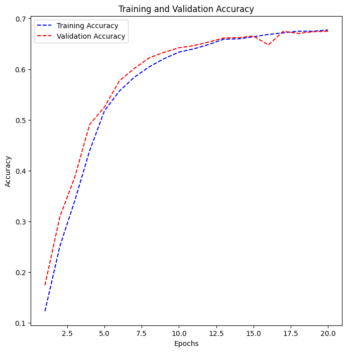

```python
#plotting the training and validation accuracy

# Extracting accuracy and validation accuracy from the history object
accuracy = history_model_1.history['accuracy']
val_accuracy = history_model_1.history['val_accuracy']

# Generating a range for epochs starting from 1 to the length of the accuracy list
epochs = range(1, len(accuracy) + 1)

# Creating a plot
plt.figure(figsize=(8, 8))

# Plotting both the training accuracy and validation accuracy
plt.plot(epochs, accuracy, 'b--', label='Training Accuracy')  # Blue dashed line for training accuracy
plt.plot(epochs, val_accuracy, 'r--', label='Validation Accuracy')  # Red dashed line for validation accuracy

# Adding labels and title for clarity
plt.title('Training and Validation Accuracy')
plt.xlabel('Epochs')
plt.ylabel('Accuracy')

# Showing the legend
plt.legend()

# Displaying the plot
plt.show()
```

```python
accuracy = model_1.evaluate(X_test_normalized, y_test_encoded, verbose=2)
```

```
563/563 - 1s - loss: 1.0453 - accuracy: 0.6781 - 978ms/epoch - 2ms/step
```

Let's build one more model with higher complexity and see if we can improve the performance of the model.

First, we need to clear the previous model's history from the Keras backend. Also, let's fix the seed again after clearing the backend.

```python
# Clearing backend

from tensorflow.keras import backend

backend.clear_session()
```

```python
# Fixing the seed for random number generators

np.random.seed(42)

import random

random.seed(42)

tf.random.set_seed(42)
```

### **Second Model Architecture**

- Write a function that returns a sequential model with the following architecture:
  - First hidden layer with **256 nodes and the relu activation** and the **input shape = (1024, )**
  - Second hidden layer with **128 nodes and the relu activation**
  - Add the **Dropout layer with the rate equal to 0.2**
  - Third hidden layer with **64 nodes and the relu activation**
  - Fourth hidden layer with **64 nodes and the relu activation**
  - Fifth hidden layer with **32 nodes and the relu activation**
  - Add the **BatchNormalization layer**
  - Output layer with **activation as 'softmax' and number of nodes equal to the number of classes, i.e., 10** -Compile the model with the **loss equal to categorical_crossentropy, optimizer equal to Adam(learning_rate = 0.0005), and metric equal to 'accuracy'**. Do not fit the model here, just return the compiled model.
- Call the nn_model_2 function and store the model in a new variable.
- Print the summary of the model.
- Fit on the train data with a **validation split of 0.2, batch size = 128, verbose = 1, and epochs = 30**. Store the model building history to use later for visualization.

### **Build and train the new ANN model as per the above mentioned architecture**

```python
def nn_model_2(input_shape, num_classes):
    model = Sequential()

    # First hidden layer
    model.add(Dense(256, activation='relu', input_shape=input_shape))

    # Second hidden layer
    model.add(Dense(128, activation='relu'))

    # Dropout layer
    model.add(Dropout(0.2))

    # Third hidden layer
    model.add(Dense(64, activation='relu'))

    # Fourth hidden layer
    model.add(Dense(64, activation='relu'))

    # Fifth hidden layer
    model.add(Dense(32, activation='relu'))

    # BatchNormalization layer
    model.add(BatchNormalization())

    # Output layer
    model.add(Dense(num_classes, activation='softmax'))

    # Compile the model
    model.compile(loss='categorical_crossentropy',
                  optimizer=Adam(learning_rate=0.0005),
                  metrics=['accuracy'])

    return model

# Assuming the input shape and the number of classes have been defined
input_shape = (1024,)
num_classes = 10

# Create the model
model_2 = nn_model_2(input_shape, num_classes)

# Print the model summary
model_2.summary()

# Fit the model
history_model_2 = model_2.fit(X_train_normalized, y_train_encoded, validation_split=0.2, batch_size=128, verbose=1, epochs=30)
```

```
Model: "sequential"
_________________________________________________________________
 Layer (type)                Output Shape              Param #
=================================================================
 dense (Dense)               (None, 256)               262400

 dense_1 (Dense)             (None, 128)               32896

 dropout (Dropout)           (None, 128)               0

 dense_2 (Dense)             (None, 64)                8256

 dense_3 (Dense)             (None, 64)                4160

 dense_4 (Dense)             (None, 32)                2080

 batch_normalization (BatchN  (None, 32)               128
 ormalization)

 dense_5 (Dense)             (None, 10)                330

=================================================================
Total params: 310,250
Trainable params: 310,186
Non-trainable params: 64
_________________________________________________________________
```

### **Plot the Training and Validation Accuracies and write down your Observations.**

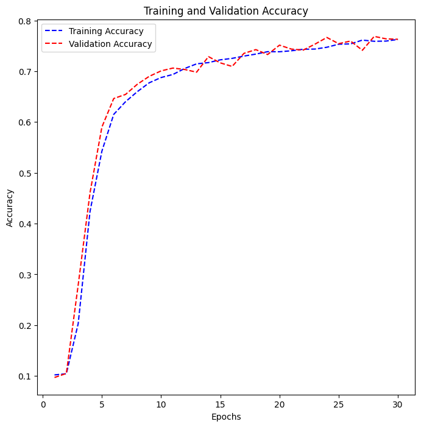

```python
#plotting the training and validation accuracy

# Extracting accuracy and validation accuracy from the history object
accuracy = history_model_2.history['accuracy']
val_accuracy = history_model_2.history['val_accuracy']

# Generating a range for epochs starting from 1 to the length of the accuracy list
epochs = range(1, len(accuracy) + 1)

# Creating a plot
plt.figure(figsize=(8, 8))

# Plotting both the training accuracy and validation accuracy
plt.plot(epochs, accuracy, 'b--', label='Training Accuracy')  # Blue dashed line for training accuracy
plt.plot(epochs, val_accuracy, 'r--', label='Validation Accuracy')  # Red dashed line for validation accuracy

# Adding labels and title for clarity
plt.title('Training and Validation Accuracy')
plt.xlabel('Epochs')
plt.ylabel('Accuracy')

# Showing the legend
plt.legend()

# Displaying the plot
plt.show()
```

```python
accuracy = model_2.evaluate(X_test_normalized, y_test_encoded, verbose=2)
```

```
563/563 - 1s - loss: 0.7689 - accuracy: 0.7596 - 1s/epoch - 2ms/step
```

## **Predictions on the test data**

- Make predictions on the test set using the second model.
- Print the obtained results using the classification report and the confusion matrix.
- Final observations on the obtained results.

```python
# 1. Make predictions on the test set using the second model.
y_pred = model_2.predict(X_test_normalized)
y_pred_arg = np.argmax(y_pred, axis=1)
```

**Note:** Earlier, we noticed that each entry of the target variable is a one-hot encoded vector but to print the classification report and confusion matrix, we must convert each entry of y_test to a single label.

```python
#convert the one-hot encoded vector to a single label
y_test_arg=np.argmax(y_test_encoded,axis=1)
```

### **Print the classification report and the confusion matrix for the test predictions. Write your observations on the final results.**

```
              precision    recall  f1-score   support

           0       0.84      0.75      0.79      1814
           1       0.74      0.79      0.77      1828
           2       0.77      0.80      0.79      1803
           3       0.62      0.77      0.69      1719
           4       0.79      0.83      0.81      1812
           5       0.76      0.68      0.72      1768
           6       0.80      0.74      0.77      1832
           7       0.83      0.77      0.80      1808
           8       0.72      0.72      0.72      1812
           9       0.75      0.74      0.75      1804

    accuracy                           0.76     18000
   macro avg       0.76      0.76      0.76     18000
weighted avg       0.76      0.76      0.76     18000
```

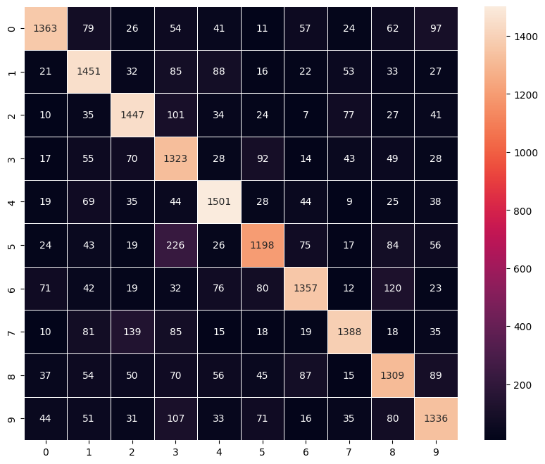

```python
# Importing required functions
from sklearn.metrics import classification_report
from sklearn.metrics import confusion_matrix

#Print results using a classification report
print(classification_report(y_test_arg, y_pred_arg))

# Plotting the Confusion Matrix using confusion matrix() function which is also predefined tensorflow module
confusion_matrix = tf.math.confusion_matrix(y_test_arg,y_pred_arg)
f, ax = plt.subplots(figsize=(10, 8))
sns.heatmap(
    confusion_matrix,
    annot=True,
    linewidths=.4,
    fmt="d",
    square=True,
    ax=ax
)
plt.show()
```

**Final Observations:**

Classification Report Interpretation:

- the pricision score across all the classes ranges from 0.62 to 0.84.
  - the class/number that is predicted with the least precoision is 3, which indicates a fairly high false positive rate for this class
- the recall score across all the classes ranges from 0.68 to 0.83
  - the class/number with the lowest recall is 5, which indicates that the model did not identify and classify a large number of true 5s -the F1-score, which balances false positives and false negatives, ranges from 0.69 to 0.81
  - class 4 has the highest F-1 score, indicating a good balance between precision and recall
  - The overall accuracy of the model is 0.76. This means that 76% of the total predictions made by the model are correct.

  Confusion Matrix Interpretation:
  - overall, the model seems to do well with predicting the correct class as the diagonal values of the matrix are high
  - there is a relatively high rate of misclassification of digit 7 is confused with 1 and 2 (81 and 139 times, respectively)
  - 5 and 2 are frequently misclassified as 3 (226 and 101 times respectively)
  - 9 is often misclassified as a 3 (107 times)

## **Using Convolutional Neural Networks**

### **Load the dataset again and split the data into the train and the test dataset.**

```python
## Loading the Dataset

import h5py

data = h5py.File('/content/drive/MyDrive/Data Science MIT/Projects/Elective Project: SVHN Digit Recognition/SVHN_single_grey1.h5', 'r')

#Show what the dataframe keys are:
data.keys()
```

```
<KeysViewHDF5 ['X_test', 'X_train', 'X_val', 'y_test', 'y_train', 'y_val']>
```

```python
#Loading the train set
X_train = data['X_train'][:]
y_train = data['y_train'][:]

#loading the test set
X_test = data['X_test'][:]
y_test = data['y_test'][:]

#loading the validation set
X_val = data['X_val'][:]
y_val = data['y_val'][:]

print(X_train)
```

[output not shown]

Check the number of images in the training and the testing dataset.

```python
print(X_train.shape) #checking the number of images in the training dataset
print(X_test.shape) #checking the number of images in the test dataset
```

```
(42000, 32, 32)
(18000, 32, 32)
```

[output not shown]

**Observation:**

- The training and test data are each stored in 3D Numpy Arrays
- the first dimension denotes the number of images in the test and training sets that are stacked ontop of each other
  - the training set comprises of 42,000 images
  - the test set comprises of 18,000 images
- the second and third dimensions in bith sets is 32 x 32, which denotes the number of pixels along the height and width of each image

## **Data preparation**

- Print the shape and the array of pixels for the first image in the training dataset.
- Reshape the train and the test dataset because we always have to give a 4D array as input to CNNs.
- Normalize the train and the test dataset by dividing by 255.
- Print the new shapes of the train and the test dataset.
- One-hot encode the target variable.

```python
#Print the shape and the array of pixels for the first image in the training dataset.
print(X_train[0].shape)
print(X_test[0])
```

```
(32, 32)
[[ 40.558   46.7917  48.9764 ... 112.1153 112.9904 112.1646]
 [ 39.4379  44.2911  47.1768 ... 111.0122 110.9475 109.9368]
 [ 38.4488  43.6394  48.7098 ... 109.8921 109.9414 109.1048]
 ...
 [ 34.9869  35.4707  39.6676 ... 109.211  109.9074 112.7346]
 [ 35.6602  35.5462  40.3193 ... 110.9998 112.049  114.3431]
 [ 36.1871  35.4214  40.6998 ... 110.0169 111.2017 114.1906]]
```

Reshape the dataset to be able to pass them to CNNs. Remember that we always have to give a 4D array as input to CNNs

```python
X_train_4D = X_train.reshape(X_train.shape[0], 32, 32, 1)

X_test_4D = X_test.reshape(X_test.shape[0], 32, 32, 1)
```

notes:

- X_train.shape[0]: This is used to get the size of the first dimension of X_train, which is the number of training samples (images) in the dataset.
  - this is the first dimension of the 4D array
- The second and third dimensions are the height and width of the images, respectively, both set to 32 pixels.
- the 4th dimension of the array is '1': this is indicative of the number of channels per image
  - because these images are greyscale, the number of channels per image is 1

Normalize inputs from 0-255 to 0-1

```python
# Normalize inputs from 0-255 to 0-1

X_train_4D_norm = X_train_4D / 255.0

X_test_4D_norm = X_test_4D / 255.0
```

Print New shape of Training and Test

```python
#checking the new shape of the test data
print(X_test_4D_norm.shape)
print(y_test.shape)

#checking the new shape of the training data
print(X_train_4D_norm.shape)
print(y_train.shape)
```

```
(18000, 32, 32, 1)
(18000,)
(42000, 32, 32, 1)
(42000,)
```

### **One-hot encode the labels in the target variable y_train and y_test.**

```python
y_train_encoded = tf.keras.utils.to_categorical(y_train) #one-hot encode labels of the y-train target variable
y_test_encoded = tf.keras.utils.to_categorical(y_test) #one-hot encode labels of the y-test target variable
```

```python
# Print the one-hot encoded test labels
print('\nOne-hot encoded test labels:\n', y_test_encoded)
```

```
One-hot encoded test labels:
 [[0. 1. 0. ... 0. 0. 0.]
 [0. 0. 0. ... 1. 0. 0.]
 [0. 0. 1. ... 0. 0. 0.]
 ...
 [0. 0. 0. ... 1. 0. 0.]
 [0. 0. 0. ... 0. 0. 1.]
 [0. 0. 1. ... 0. 0. 0.]]
```

**Observations:**

- we used the reshape method on the x_train and y_train dataset to convert the image input from 3D tensors to a 4D tensor that is suitable for feeding into the CNN
- we normalized the data to ensure that each pixel (parameter) has a similar distribution to enable faster convergence when training the network
- after one-hot encoding, each row is a vector representing a single output label
  - for example, the number '2' in the first image is represented as a 1D array/vector with zeros in all columns except for the column in the second index position, which has a 1

## **Model Building**

Now that we have done data preprocessing, let's build a CNN model. Fix the seed for random number generators

```python
# Clearing backend

from tensorflow.keras import backend

backend.clear_session()
```

```python
# Fixing the seed for random number generators

np.random.seed(42)

import random

random.seed(42)

tf.random.set_seed(42)
```

### **Model Architecture**

- **Write a function** that returns a sequential model with the following architecture:
  - First Convolutional layer with **16 filters and the kernel size of 3x3**. Use the **'same' padding** and provide the **input shape = (32, 32, 1)**
  - Add a **LeakyRelu layer** with the **slope equal to 0.1**
  - Second Convolutional layer with **32 filters and the kernel size of 3x3 with 'same' padding**
  - Another **LeakyRelu** with the **slope equal to 0.1**
  - A **max-pooling layer** with a **pool size of 2x2**
  - **Flatten** the output from the previous layer
  - Add a **dense layer with 32 nodes**
  - Add a **LeakyRelu layer with the slope equal to 0.1**
  - Add the final **output layer with nodes equal to the number of classes, i.e., 10** and **'softmax' as the activation function**
  - Compile the model with the **loss equal to categorical_crossentropy, optimizer equal to Adam(learning_rate = 0.001), and metric equal to 'accuracy'**. Do not fit the model here, just return the compiled model.
- Call the function cnn_model_1 and store the output in a new variable.
- Print the summary of the model.
- Fit the model on the training data with a **validation split of 0.2, batch size = 32, verbose = 1, and epochs = 20**. Store the model building history to use later for visualization.

### **Build and train a CNN model as per the above mentioned architecture.**

```python
def cnn_model_1(input_shape, num_classes):
    #initializing the sequential model
    model = Sequential()

    # First Convolutional layer with 16 filters and a kernal size of 3x3
    model.add(Conv2D(16, kernel_size=(3, 3), padding='same', input_shape=input_shape)) #padding 'same' ensures the output image size is the same as the input image size
    # LeakyRelu layer with a slope of 0.1
    model.add(LeakyReLU(alpha=0.1))

    # Second Convolutional layer with 32 filters and a kernal size of 3x3
    model.add(Conv2D(32, kernel_size=(3, 3), padding='same'))
    # LeakyRelu layer with a slope of 0.1
    model.add(LeakyReLU(alpha=0.1))

    # Max-pooling layer with a pool size of 2x2
    model.add(MaxPooling2D(pool_size=(2, 2)))

    # Flatten the output
    model.add(Flatten())

    # Dense layer with 32 nodes
    model.add(Dense(32))
    # LeakyRelu layer with a slope of 0.1
    model.add(LeakyReLU(alpha=0.1))

    # Output layer with nodes equal to the 'num_classes' and the softmax activation function
    model.add(Dense(num_classes, activation='softmax'))

    # Compile the model  with the loss equal to categorical_crossentropy, optimizer equal to Adam(learning_rate = 0.001), and metric equal to 'accuracy'.
    model.compile(loss='categorical_crossentropy',
                  optimizer=Adam(learning_rate=0.001),
                  metrics=['accuracy'])

    return model

# defining the function inputs
input_shape = (32, 32, 1)
num_classes = 10

# Create the model and save it in new object called cnn_model1
cnn_model1 = cnn_model_1(input_shape, num_classes)

# Print the model summary
print(cnn_model1.summary())

# Fit the model on the training data
cnn_history_1 = cnn_model1.fit(X_train_4D_norm, y_train_encoded, validation_split=0.2, batch_size=32, verbose=1, epochs=20)
```

```
Model: "sequential"
_________________________________________________________________
 Layer (type)                Output Shape              Param #
=================================================================
 conv2d (Conv2D)             (None, 32, 32, 16)        160

 leaky_re_lu (LeakyReLU)     (None, 32, 32, 16)        0

 conv2d_1 (Conv2D)           (None, 32, 32, 32)        4640

 leaky_re_lu_1 (LeakyReLU)   (None, 32, 32, 32)        0

 max_pooling2d (MaxPooling2D  (None, 16, 16, 32)       0
 )

 flatten (Flatten)           (None, 8192)              0

 dense (Dense)               (None, 32)                262176

 leaky_re_lu_2 (LeakyReLU)   (None, 32)                0

 dense_1 (Dense)             (None, 10)                330

=================================================================
Total params: 267,306
Trainable params: 267,306
Non-trainable params: 0
_________________________________________________________________
None
```

### **Plot the Training and Validation Accuracies and Write your observations.**

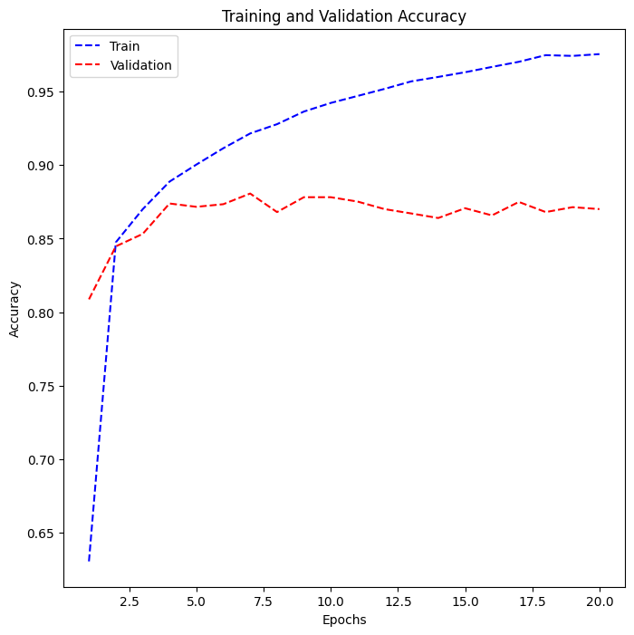

```python
#plotting the training and validation accuracy

# Extracting accuracy and validation accuracy from the cnn_history_1 object
accuracy = cnn_history_1.history['accuracy']
val_accuracy = cnn_history_1.history['val_accuracy']

# Generating a range for epochs starting from 1 to the length of the accuracy list
epochs = range(1, len(accuracy) + 1)

# Creating a plot
plt.figure(figsize=(8, 8))

# Plotting both the training accuracy and validation accuracy
plt.plot(epochs, accuracy, 'b--', label='Training Accuracy')  # Blue dashed line for training accuracy
plt.plot(epochs, val_accuracy, 'r--', label='Validation Accuracy')  # Red dashed line for validation accuracy

# Adding labels and title for clarity
plt.title('Training and Validation Accuracy')
plt.xlabel('Epochs')
plt.ylabel('Accuracy')

# Showing the legend
plt.legend(['Train', 'Validation'], loc='upper left')


# Displaying the plot
plt.show()
```

```python
accuracy = cnn_model1.evaluate(X_test_4D_norm, y_test_encoded, verbose=2)
```

```
563/563 - 11s - loss: 0.8330 - accuracy: 0.8689 - 11s/epoch - 19ms/step
```

Let's build another model and see if we can get a better model with generalized performance.

First, we need to clear the previous model's history from the Keras backend. Also, let's fix the seed again after clearing the backend.

```python
# Clearing backend

from tensorflow.keras import backend

backend.clear_session()
```

```python
# Fixing the seed for random number generators

np.random.seed(42)

import random

random.seed(42)

tf.random.set_seed(42)
```

### **Second Model Architecture**

- Write a function that returns a sequential model with the following architecture:
  - First Convolutional layer with **16 filters and the kernel size of 3x3**. Use the **'same' padding** and provide the **input shape = (32, 32, 1)**
  - Add a **LeakyRelu layer** with the **slope equal to 0.1**
  - Second Convolutional layer with **32 filters and the kernel size of 3x3 with 'same' padding**
  - Add **LeakyRelu** with the **slope equal to 0.1**
  - Add a **max-pooling layer** with a **pool size of 2x2**
  - Add a **BatchNormalization layer**
  - Third Convolutional layer with **32 filters and the kernel size of 3x3 with 'same' padding**
  - Add a **LeakyRelu layer with the slope equal to 0.1**
  - Fourth Convolutional layer **64 filters and the kernel size of 3x3 with 'same' padding**
  - Add a **LeakyRelu layer with the slope equal to 0.1**
  - Add a **max-pooling layer** with a **pool size of 2x2**
  - Add a **BatchNormalization layer**
  - **Flatten** the output from the previous layer
  - Add a **dense layer with 32 nodes**
  - Add a **LeakyRelu layer with the slope equal to 0.1**
  - Add a **dropout layer with the rate equal to 0.5**
  - Add the final **output layer with nodes equal to the number of classes, i.e., 10** and **'softmax' as the activation function**
  - Compile the model with the **categorical_crossentropy loss, adam optimizers (learning_rate = 0.001), and metric equal to 'accuracy'**. Do not fit the model here, just return the compiled model.
- Call the function cnn_model_2 and store the model in a new variable.
- Print the summary of the model.
- Fit the model on the train data with a **validation split of 0.2, batch size = 128, verbose = 1, and epochs = 30**. Store the model building history to use later for visualization.

### **Build and train the second CNN model as per the above mentioned architecture.**

```python
def cnn_model_2(input_shape, num_classes):
    # Initialize the Sequential model
    model = Sequential()

    # First Convolutional layer with 16 filters of size 3x3 and 'same' padding ensures output is the same size as the input
    model.add(Conv2D(16, kernel_size=(3, 3), padding='same', input_shape=input_shape))
    # Add LeakyReLU activation with slope of 0.1
    model.add(LeakyReLU(alpha=0.1))

    # Second Convolutional layer with 32 filters of size 3x3 and 'same' padding
    model.add(Conv2D(32, kernel_size=(3, 3), padding='same'))
    # Add LeakyReLU activation with slope of 0.1
    model.add(LeakyReLU(alpha=0.1))

    # MaxPooling layer to reduce spatial dimensions by taking the maximum value over 2x2 patches
    model.add(MaxPooling2D(pool_size=(2, 2)))
    # BatchNormalization layer to normalize the activations of the previous layer at each batch
    model.add(BatchNormalization())

    # Third Convolutional layer with 32 filters of size 3x3 and 'same' padding
    model.add(Conv2D(32, kernel_size=(3, 3), padding='same'))
    # Add LeakyReLU activation with slope of 0.1
    model.add(LeakyReLU(alpha=0.1))

    # Fourth Convolutional layer with 64 filters of size 3x3 and 'same' padding
    model.add(Conv2D(64, kernel_size=(3, 3), padding='same'))
    # Add LeakyReLU activation with slope of 0.1
    model.add(LeakyReLU(alpha=0.1))

    # Another MaxPooling layer with a pool size of 2x2
    model.add(MaxPooling2D(pool_size=(2, 2)))
    # Another BatchNormalization layer
    model.add(BatchNormalization())

    # Flatten the output of the previous layer to prepare it for the dense layers
    model.add(Flatten())

    # Dense layer with 32 nodes
    model.add(Dense(32))
    # Add LeakyReLU activation with slope of 0.1
    model.add(LeakyReLU(alpha=0.1))

    # Dropout layer to prevent overfitting by randomly setting a fraction rate of input units to 0 at each update during training time
    model.add(Dropout(0.5))

    # Output layer with a number of nodes corresponding to the number of classes and softmax activation
    model.add(Dense(num_classes, activation='softmax'))

    # Compile the model with the categorical crossentropy loss, the adam optimizer, and accuracy as a metric
    model.compile(loss='categorical_crossentropy',
                  optimizer=Adam(learning_rate=0.001),
                  metrics=['accuracy'])

    return model

# Defining the function inputs
input_shape = (32, 32, 1)
num_classes = 10

# Create the model using the defined function and save it in new object called 'cnn_model2'
cnn_model2 = cnn_model_2(input_shape, num_classes)

# Print the summary of the model to verify the architecture
print(cnn_model2.summary())

cnn_history_2 = cnn_model2.fit(X_train, y_train_encoded, validation_split=0.2, batch_size=128, verbose=1, epochs=30)
```

```
Model: "sequential"
_________________________________________________________________
 Layer (type)                Output Shape              Param #
=================================================================
 conv2d (Conv2D)             (None, 32, 32, 16)        160

 leaky_re_lu (LeakyReLU)     (None, 32, 32, 16)        0

 conv2d_1 (Conv2D)           (None, 32, 32, 32)        4640

 leaky_re_lu_1 (LeakyReLU)   (None, 32, 32, 32)        0

 max_pooling2d (MaxPooling2D  (None, 16, 16, 32)       0
 )

 batch_normalization (BatchN  (None, 16, 16, 32)       128
 ormalization)

 conv2d_2 (Conv2D)           (None, 16, 16, 32)        9248

 leaky_re_lu_2 (LeakyReLU)   (None, 16, 16, 32)        0

 conv2d_3 (Conv2D)           (None, 16, 16, 64)        18496

 leaky_re_lu_3 (LeakyReLU)   (None, 16, 16, 64)        0

 max_pooling2d_1 (MaxPooling  (None, 8, 8, 64)         0
 2D)

 batch_normalization_1 (Batc  (None, 8, 8, 64)         256
 hNormalization)

 flatten (Flatten)           (None, 4096)              0

 dense (Dense)               (None, 32)                131104

 leaky_re_lu_4 (LeakyReLU)   (None, 32)                0

 dropout (Dropout)           (None, 32)                0

 dense_1 (Dense)             (None, 10)                330

=================================================================
Total params: 164,362
Trainable params: 164,170
Non-trainable params: 192
_________________________________________________________________
None
```

### **Plot the Training and Validation accuracies and write your observations.**

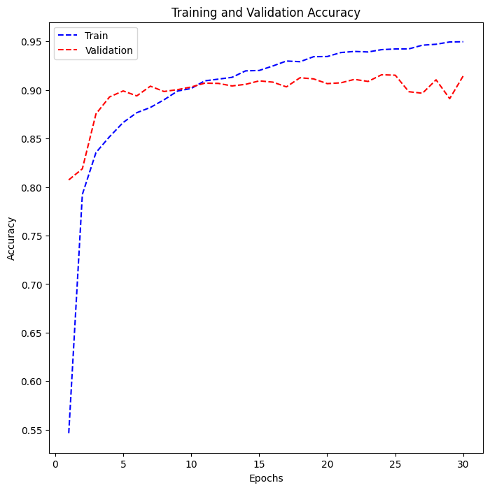

```python
#plotting the training and validation accuracy

# Extracting accuracy and validation accuracy from the cnn_history_1 object
accuracy = cnn_history_2.history['accuracy']
val_accuracy = cnn_history_2.history['val_accuracy']

# Generating a range for epochs starting from 1 to the length of the accuracy list
epochs = range(1, len(accuracy) + 1)

# Creating a plot
plt.figure(figsize=(8, 8))

# Plotting both the training accuracy and validation accuracy
plt.plot(epochs, accuracy, 'b--', label='Training Accuracy')  # Blue dashed line for training accuracy
plt.plot(epochs, val_accuracy, 'r--', label='Validation Accuracy')  # Red dashed line for validation accuracy

# Adding labels and title for clarity
plt.title('Training and Validation Accuracy')
plt.xlabel('Epochs')
plt.ylabel('Accuracy')

# Showing the legend
plt.legend(['Train', 'Validation'], loc='upper left')


# Displaying the plot
plt.show()
```

```python
accuracy = cnn_model2.evaluate(X_test_4D_norm, y_test_encoded, verbose=2)
```

```
563/563 - 22s - loss: 3.1418 - accuracy: 0.1007 - 22s/epoch - 38ms/step
```

## **Predictions on the test data**

- Make predictions on the test set using the second model.
- Print the obtained results using the classification report and the confusion matrix.
- Final observations on the obtained results.

### **Make predictions on the test data using the second model.**

```python
# 1. Make predictions on the test set using the second model.
y_pred = cnn_model2.predict(X_test_4D_norm)
y_pred_arg = np.argmax(y_pred, axis=1)
```

**Note:** Earlier, we noticed that each entry of the target variable is a one-hot encoded vector, but to print the classification report and confusion matrix, we must convert each entry of y_test to a single label.

```python
#convert the one-hot encoded vector to a single label
y_test_arg=np.argmax(y_test_encoded,axis=1)
```

### **Write your final observations on the performance of the model on the test data.**

```
              precision    recall  f1-score   support

           0       0.00      0.00      0.00      1814
           1       0.00      0.00      0.00      1828
           2       0.00      0.00      0.00      1803
           3       0.00      0.00      0.00      1719
           4       0.10      1.00      0.18      1812
           5       0.00      0.00      0.00      1768
           6       0.00      0.00      0.00      1832
           7       0.00      0.00      0.00      1808
           8       0.00      0.00      0.00      1812
           9       0.00      0.00      0.00      1804

    accuracy                           0.10     18000
   macro avg       0.01      0.10      0.02     18000
weighted avg       0.01      0.10      0.02     18000
```

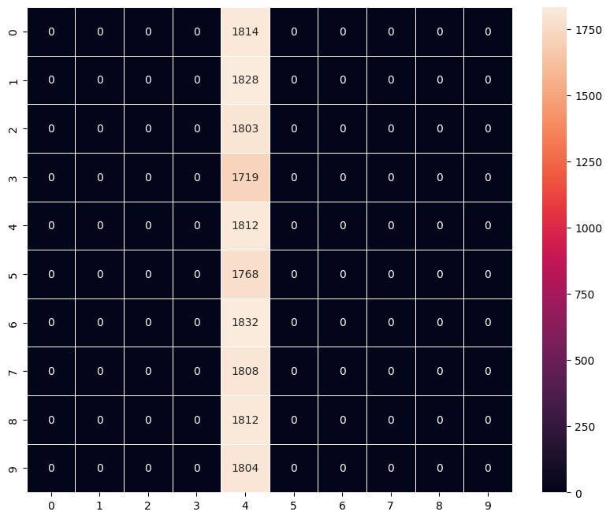

```python
# Importing required functions

from sklearn.metrics import classification_report

from sklearn.metrics import confusion_matrix

#Print results using a classification report
print(classification_report(y_test_arg, y_pred_arg))

# Plotting the Confusion Matrix using confusion matrix() function which is also predefined tensorflow module
confusion_matrix = tf.math.confusion_matrix(y_test_arg,y_pred_arg)
f, ax = plt.subplots(figsize=(10, 8))
sns.heatmap(
    confusion_matrix,
    annot=True,
    linewidths=.4,
    fmt="d",
    square=True,
    ax=ax
)
plt.show()
```